# Principios de Estadística Aplicada con R

Estadística descriptiva

Gabriel Carrasco Escobar

Universidad Peruana Cayetano Heredia

Jorge Ruiz Cabrejos

Universidad Peruana Cayetano Heredia

08 de febrero del 2018

Rutinas y comandos complementarios del curso *Principios de Estadística Aplicada con R (PEAR)*

*Cualquier problema con este código, porfavor contactar a gabriel.carrasco@upch.pe*

En esta sección utilizamos distintas herramientas con ayuda de la plataforma R para realizar el análisis descriptivo de las variables.

Los paquetes que se utilizaran son:

```r
library(epiDisplay)
library(doBy)
library(moments)
library(sfsmisc)
library(modeest)
library(dplyr)
```

Los ejercicios de la primera parte utilizarán las variables de la base de datos `Winzell2004_covar_v2.csv`. Esta deberá ser descargada e importada a R.

Para ello, podemos empezar utilizando `rm(list=ls())` y asi eliminar todos los objetos creados hasta ahora e iniciar con un entorno o *Environment* de R limpio.

Esto quiere decir que las variables e información creados previamente dentro de R se eliminara.

```r
rm(list=ls())
```

Con el entorno limpio, procedemos a descargar la base, a la que llamaremos `df`. Así, evitamos escribir el nombre `Winzell2004_covar_v2.csv` cada vez que necesitemos referenciarla.

```r
df <- read.csv("C:/Usuario/Estudiante/Escritorio/Estadistica/DatabasesWinzell2004_covar_v2.csv")
```

La base de datos `df` tiene las siguientes variables:

| Descripción: | código: |
| --- | --- |
| Sexo | Sex |
| Dieta | Diet |
| Peso | Bodyweight |
| Glucosa(mmol/l) | glucose |
| Ingesta energética (KJ/day) | en_intake |
| Insulina (pmol/l) | insulin |
| Metabolic Efficiency | meta_eff |
| Early insulin response (pmol/l) | ein_resp |
| Tiempo | time |

## Análisis de una variable

### Tab1

La función `tab1` genera un gráfico de barras de **una** variable (tabulación de un solo sentido o sentido único).

En el siguiente ejemplo, utilizamos la función `tab1` con la variable `Diet` para visualizar la distribución de las dietas `chow` y `hf`.

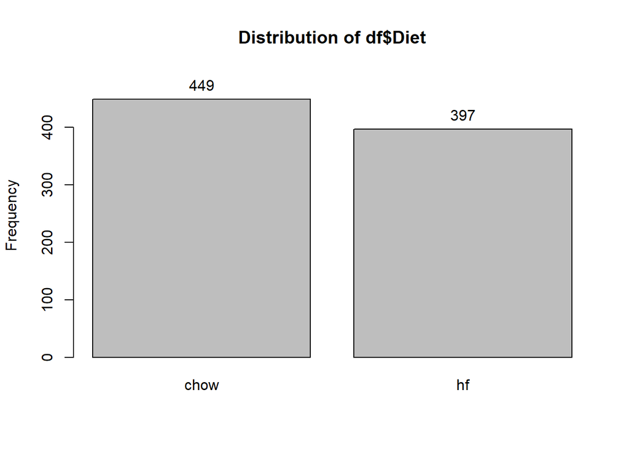

```
## df$Diet :
##         Frequency Percent Cum. percent
## chow          449    53.1         53.1
## hf            397    46.9        100.0
##   Total       846   100.0        100.0
```

```r
tab1(df$Diet)
```

La consola de R nos brindara una tabla de resumen, en el que se indica la frequencia, porcentaje y porcentaje acumulado de las variables que utilizamos.

### Stem

Con la función `stem` generamos un gráfico de texto, conocido como diagrama de tallos y hojas, el cual nos permite visualizar la distribución de un grupo de observaciones.

En este caso, utilizamos la variable `glucose`.

```r
stem(df$glucose)
```

```
##
##   The decimal point is 1 digit(s) to the left of the |
##
##   56 | 5
##   58 | 236
##   60 | 2246802245569
##   62 | 000134800111344567777888888
##   64 | 00002233334556666677788888889990011222333334444444555555666677777788
##   66 | 00000002222222233333344444444445555566677777888890000000000011111122+37
##   68 | 00000000111122222233333344444444555555566666667788888888889999999999+98
##   70 | 00000000001111222222223333333333344444444445555566666666667777777788+82
##   72 | 00000000000011111111222222222222333333334444444455555555555556666666+68
##   74 | 00111111111222223333333444455666777778888990000022223333455555667777
##   76 | 00122234788901236999
##   78 | 0112245781123689
##   80 | 12386
##   82 | 12
```

### hist

Similar a la función `stem`, la función `hist` nos permite visualizar esta información a través de un histograma.

Nuevamente, utilizamos la variable `glucose` para la visualización.

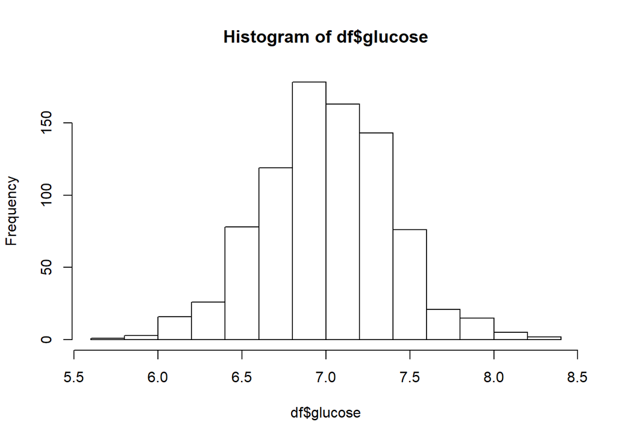

```r
hist(df$glucose)
```

Esta información puede ser modificada y personalizada agregando opciones a nuestro código.

Alguna de estas opciones son:

- `main="Título"` para modificar/agregar el título del gráfico.
- `xlab="nombre"` y `ylab="nombre"` para modificar las palabras que aparecen en el eje X y eje Y respectivamente.

En este caso, colocaremos en el eje X “Glucosa”, en el eje Y “Frecuencia”, y como título “Glucosa en ratones”

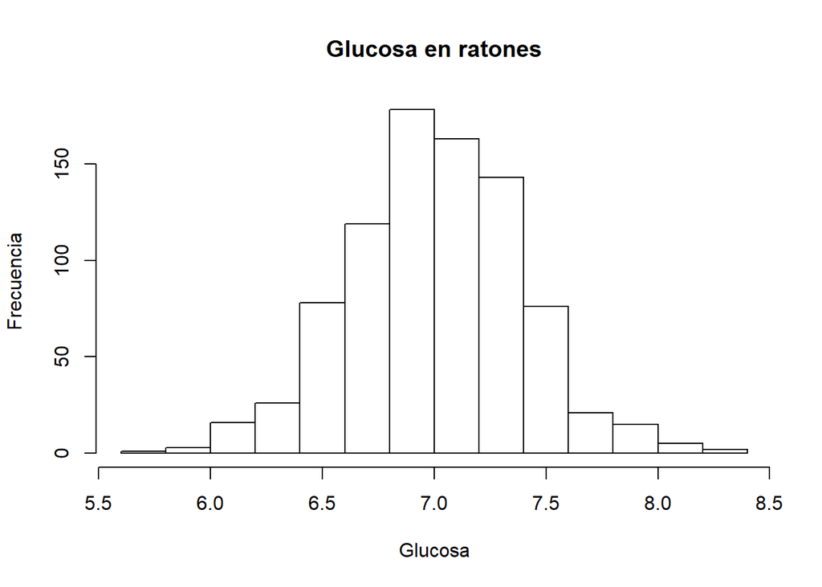

```r
hist(df$glucose, xlab="Glucosa", ylab="Frecuencia", main="Glucosa en ratones")
```

### boxplot

Utilizamos la función `boxplot` para generar diagramas de caja (*boxplots*).

Para el ejemplo, colocamos la variable `glucose`

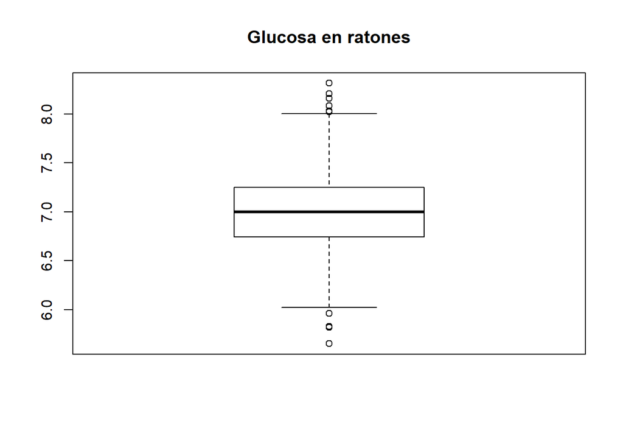

```r
boxplot(df$glucose, main="Glucosa en ratones")
```

### histBxp

Con la función `histBxp` podemos visualizar un histograma y un *boxplot* en un mismo gráfico.

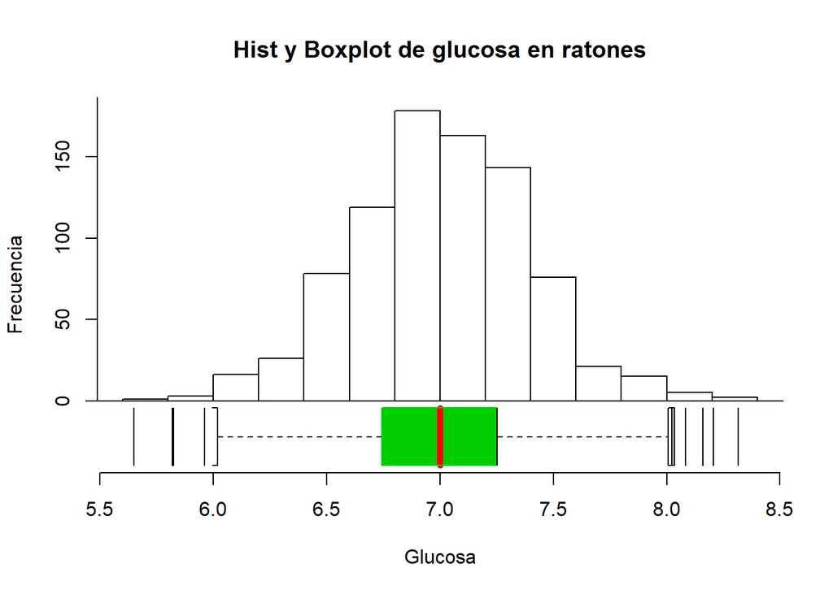

```r
histBxp(df$glucose, main="Hist y Boxplot de glucosa en ratones", xlab="Glucosa", ylab="Frecuencia")
```

## Medidas de tendencia central

### Media aritmética

Con `mean` calculamos la media (promedio) de una variable. En este caso, `glucose`.

```r
mean(df$glucose)
```

```
## [1] 7.006728
```

### Mediana

A diferencia de la media, la mediana nos permite identificar el valor que divide una ditribución ordenada por la mitad

Utilizamos la función `median` con la variable `glucose`

```r
median(df$glucose)
```

```
## [1] 7.00021
```

### Moda

Nos da como resultado el valor más frecuente; suele ser utilizado para variables categóricas

Hallamos la moda de `glucose` con la función `mfv` del paquete modeest.

```r
mfv(df$glucose)
```

```
## [1] 7.029131
```

R nos permite crear nuestras propias funciones.

A continuación, creamos una función para la moda.

```r
gce_mode <- function(x) {
  uniqx <- unique(x)
  uniqx[which.max(tabulate(match(x, uniqx)))]
}
```

Esta nos dará el mismo resultado que `mfv`

```r
gce_mode(df$glucose)
```

```
## [1] 7.029131
```

A continuación, creamos la función `gce_mean` para hallar la media, al igual que `mean`.

```r
gce_mean <- function (x) {sum(x)/length(x)}
```

Una vez creada, comprobamos su funcionalidad.

```r
gce_mean(df$glucose)
```

```
## [1] 7.006728
```

### Summary y abline

```r
summary(df$glucose)
```

```
##    Min. 1st Qu.  Median    Mean 3rd Qu.    Max.
##   5.650   6.744   7.000   7.007   7.251   8.316
```

Utilizando la función `abline` en conjunto a la función `hist` podemos graficar y colocar estos valores como líneas en el histograma.

Colocaremos una linea roja en la media, una linea azul en la mediana y una línea verde en la moda

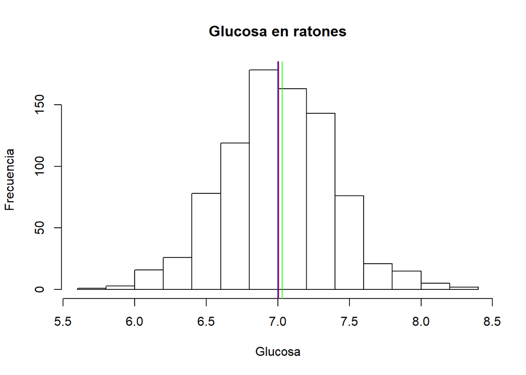

```r
hist(df$glucose, main="Glucosa en ratones", xlab="Glucosa", ylab="Frecuencia")
abline(v=mean(df$glucose), col = 'red')
abline(v=median(df$glucose), col = 'blue')
abline(v=mfv(df$glucose), col = 'green')
```

### Ejercicio N° 1

- *EJERCICIO* Realiza el histograma de las variables `en_intake` y `time`. Utiliza la función`abline` para complementar tus hallazgos.

## Medidas de dispersión

### Rango

Se conoce como rango a la diferencia entre el valor máximo y el mínimo observados. Se lo conoce también como aplitud total o recorrido.

Utilizamos la función `min` y `max` para hallar los valores mínimos y máximos de una variable respectivamente.

```r
c(min(df$glucose),max(df$glucose))
```

```
## [1] 5.650370 8.315831
```

Para hallar el rango, utilizamos la función `range`. Comprobamos que el resultado sea igual al de `min` y `max`.

```r
range(df$glucose)
```

```
## [1] 5.650370 8.315831
```

### Rango intercuartil (RIC)

Con la función `IQR` hallamos el rango intercuartil (percentiles 25 y 75)

```r
IQR(df$glucose)
```

```
## [1] 0.5067847
```

### Desviación estándar

Con la desviación estándar calculamos el monto promedio en el que se desvían los valores observados respecto a su media artimética.

En R utilizamos la función `sd`.

```r
sd(df$glucose)
```

```
## [1] 0.383118
```

### Varianza poblacional y muestral

La varianza poblacional y muestral son distintas. Podemos observar esta diferencia al crear la función respectiva para cada una.

#### Varianza poblacional

```r
variance_pop <- function (x) {sum((x-mean(x))^2)/length(x)}
```

Hallamos la varianza poblacional de `glucose`

```r
variance_pop(df$glucose)
```

```
## [1] 0.1466059
```

#### Varianza muestral

```r
variance_samp <- function (x) {sum((x-mean(x))^2)/(length(x)-1)}
```

Hallamos la varianza muestral de `glucose`

```r
variance_samp(df$glucose)
```

```
## [1] 0.1467794
```

#### Función var

También podemos utilizar la función `var` para obtener el resultado de la varianza muestral.

```r
var(df$glucose)
```

```
## [1] 0.1467794
```

### Coeficiente de variación

La fórmula para la función del coeficiente de variación es el siguiente:

```r
gce_cv <- function (x) {sd(x)/mean(x)}
```

Con la variable glucosa, el coeficiente de variación nos da el siguiente resultado:

```r
gce_cv(df$glucose)
```

```
## [1] 0.05467859
```

### Ejercicio N° 2

- *EJERCICIO* Compara la dispersion de `meta_eff` y `ein_resp`

## Medidas de locación y forma

Para explicar y entender mejor la distribución de los datos de una variable, utilizamos las medidas de asimetría estadística (skewness) y curtosis.

### Skewness

Con la funcion `skewness` calculamos la asimetría estadística.

```r
skewness(df$glucose)
```

```
## [1] 0.001212523
## attr(,"method")
## [1] "moment"
```

### Kurtosis

La curtosis es calculada con la función `kurtosis`.

```r
kurtosis(df$glucose)
```

```
## [1] 3.355597
```

### Ejercicio N° 3

- *EJERCICIO A* Explora y compara `en_intake` y `ein_resp`en terminos de skewness
- *EJERCICIO B* Explora y compara `insulin` y `meta_eff`en terminos de Curtosis

## Comparando dos variables

Con la función `boxplot` podemos realizar un gráfico para el análisis de dos variables.

A continuación, generamos el gráfico con `Bodyweight` y `Diet`

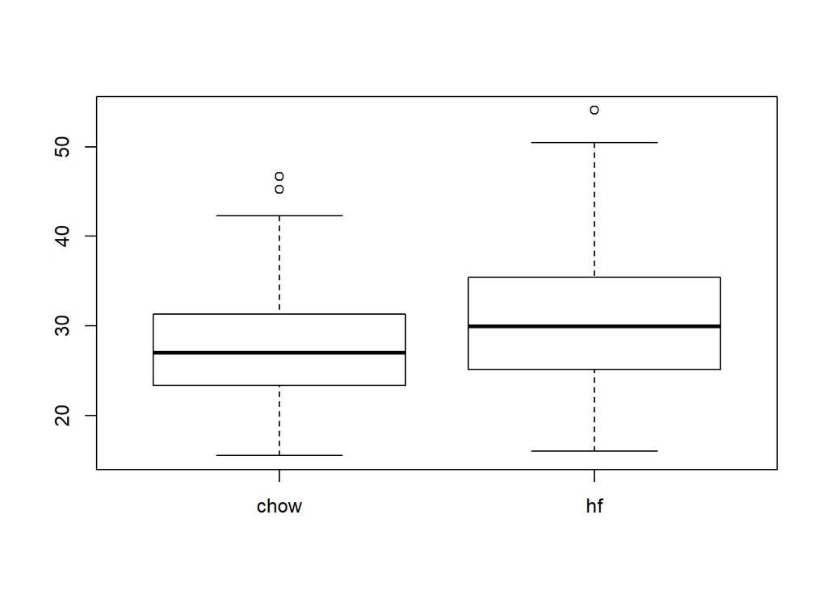

```r
boxplot(Bodyweight~Diet,data=df)
```

Añadimos `col="color"` para escoger los colores del gráfico.

Para este gráfico, escogemos dos colores añadiendo `col=(c("color1","color2"))`

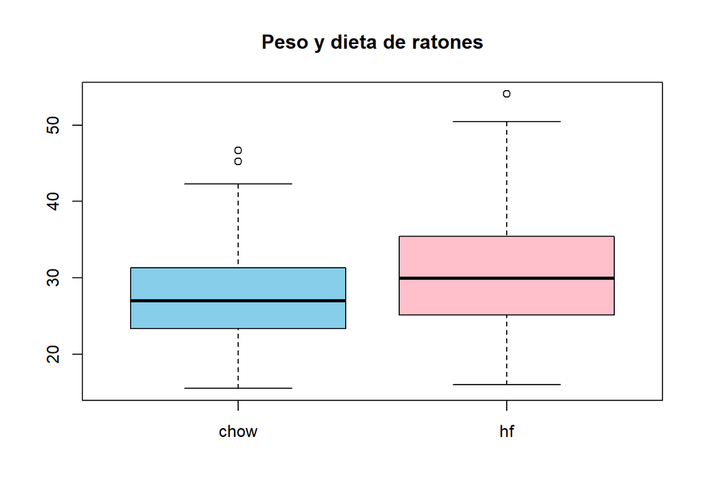

```r
boxplot(Bodyweight~Diet,data=df, col=(c("skyblue","pink")), main="Peso y dieta de ratones")
```

### tabpct

La función `tabpct` nos permite comparar dos variables categoricas con gráficos de barra.

A continuación, utilizamos `tabpct` para comparar la dieta y sexo de los ratones.

```r
tabpct(df$Sex,df$Diet)
```

```
##
## Original table
##        df$Diet
## df$Sex   chow   hf  Total
##   F       225  200    425
##   M       224  197    421
##   Total   449  397    846
##
## Row percent
##       df$Diet
## df$Sex    chow      hf  Total
##      F     225     200    425
##         (52.9)  (47.1)  (100)
##      M     224     197    421
##         (53.2)  (46.8)  (100)
##
## Column percent
##        df$Diet
## df$Sex   chow       %   hf       %
##   F       225  (50.1)  200  (50.4)
##   M       224  (49.9)  197  (49.6)
##   Total   449   (100)  397   (100)
```

[figure not shown]

### plot

Para comparar dos variables continuas en un gráfico de dispersión, utilizamos la función `plot`.

Para el ejemplo usaremos las variables `Bodyweight` y `glucose`

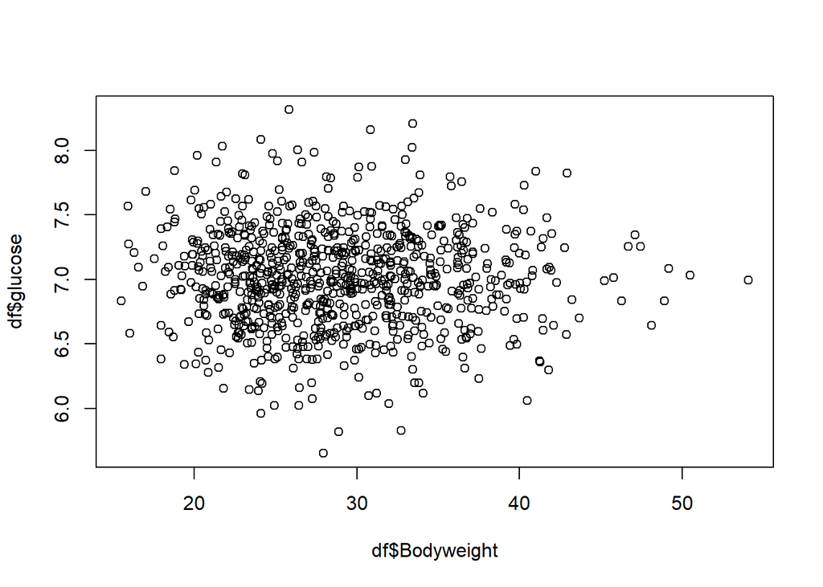

```r
plot(df$Bodyweight,df$glucose)
```

## Introducción a dplyr

Recomendamos utilizar `rm(list=ls())` antes de seguir.

Los ejercicios a continuación utilizan las variables de la base de datos `femaleMiceWeights.csv`, la cuál a sido renombrada como `dat`. Esta deberá ser descargada e importada a R.

```r
dat <- read.csv("C:/Usuario/Estudiante/Escritorio/Estadistica/femaleMiceWeights.csv")
```

### Filtro y selección de datos

La función `filter` nos permite filtrar/escoger los datos de una tabla que sean de nuestro interes. En este caso, nos interesa quedarnos solo con aquellas observaciones que tuvieron como dieta “chow”.

```r
chow <- filter(dat, Diet=="chow")
chow
```

```
##    Diet Bodyweight
## 1  chow      21.51
## 2  chow      28.14
## 3  chow      24.04
## 4  chow      23.45
## 5  chow      23.68
## 6  chow      19.79
## 7  chow      28.40
## 8  chow      20.98
## 9  chow      22.51
## 10 chow      20.10
## 11 chow      26.91
## 12 chow      26.25
```

Ahora, utilizando la función `dplyr::select` conservaremos los valores del peso de las observaciones antes filtradas. Conservamos esta información en el objeto `chowVals`

```r
chowVals <- dplyr::select(chow,Bodyweight)
chowVals
```

```
##    Bodyweight
## 1       21.51
## 2       28.14
## 3       24.04
## 4       23.45
## 5       23.68
## 6       19.79
## 7       28.40
## 8       20.98
## 9       22.51
## 10      20.10
## 11      26.91
## 12      26.25
```

Para eliminar uno o varios objetos de la consola se utiliza la función `rm`.

```r
rm(chow, chowVals)
```

### Comando “pipe”

El procedimiento anterior puede ser realizado de forma más eficiente utilizando el comando `%>%`

```r
chowVals <- filter(dat, Diet=="chow") %>% dplyr::select(Bodyweight)
chowVals
```

```
##    Bodyweight
## 1       21.51
## 2       28.14
## 3       24.04
## 4       23.45
## 5       23.68
## 6       19.79
## 7       28.40
## 8       20.98
## 9       22.51
## 10      20.10
## 11      26.91
## 12      26.25
```

### summaryBy

Con la función `summaryBy` comparamos dos variables utilizando distintas medidas.

```r
summaryBy(Bodyweight~Diet, data=dat, FUN=c(mean, sd, median, length, skewness, kurtosis))
```

```
##   Diet Bodyweight.mean Bodyweight.sd Bodyweight.median Bodyweight.length
## 1 chow        23.81333      3.022541            23.565                12
## 2   hf        26.83417      4.097606            26.040                12
##   Bodyweight.skewness Bodyweight.kurtosis
## 1           0.2055259            1.744207
## 2           0.1709926            2.024739
```

### Funciones dplyr vs funciones base

Un resultado similar se puede obtener utilizando la función `subset`, el cual no requiere de la libreria de dplyr

```r
chow1 <- subset(dat,dat$Diet=="chow")
chowVals1 <- subset(chow1, select=c(2))
chowVals1
```

```
##    Bodyweight
## 1       21.51
## 2       28.14
## 3       24.04
## 4       23.45
## 5       23.68
## 6       19.79
## 7       28.40
## 8       20.98
## 9       22.51
## 10      20.10
## 11      26.91
## 12      26.25
```

```r
chowVals2 <- subset(dat, dat$Diet=="chow", select=c(2))
chowVals2
```

```
##    Bodyweight
## 1       21.51
## 2       28.14
## 3       24.04
## 4       23.45
## 5       23.68
## 6       19.79
## 7       28.40
## 8       20.98
## 9       22.51
## 10      20.10
## 11      26.91
## 12      26.25
```

Asimismo, la función `unlist` nos permite convertir un objeto vector

```r
chowVals<-unlist(chowVals)
class(chowVals)
```

```
## [1] "numeric"
```

Utilizando pipes `%>%` tendríamos una línea asi

```r
chowVals <- filter(dat, Diet=="chow") %>% dplyr::select(Bodyweight) %>% unlist
chowVals
```

```
##  Bodyweight1  Bodyweight2  Bodyweight3  Bodyweight4  Bodyweight5
##        21.51        28.14        24.04        23.45        23.68
##  Bodyweight6  Bodyweight7  Bodyweight8  Bodyweight9 Bodyweight10
##        19.79        28.40        20.98        22.51        20.10
## Bodyweight11 Bodyweight12
##        26.91        26.25
```

En este caso, tener `chowVals` como vector nos permite utilizar la función `mean` para hallar la media

```r
mean(chowVals)
```

```
## [1] 23.81333
```

De no realizar el procedimiento previo de filtrado y selección, para hallar la media con `mean` utilizamos lo siguiente

```r
mean(dat[dat$Diet=="chow","Bodyweight"])
```

```
## [1] 23.81333
```

## Solucionario

### Ejercicio N° 1

- *EJERCICIO* Realiza el histograma de las variables `en_intake` y `time`. Utiliza la función`abline` para complementar tus hallazgos.

Para `en_intake`:

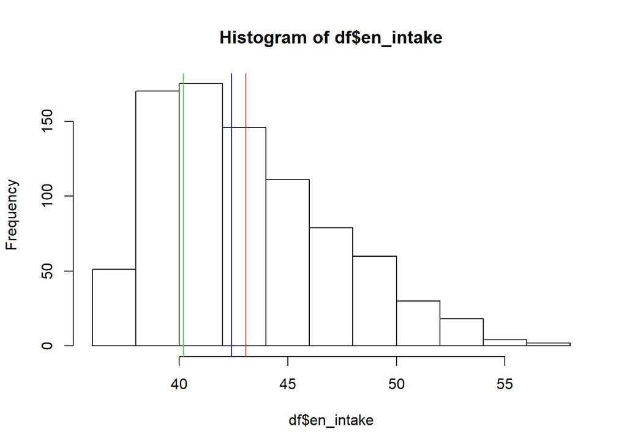

```r
media <- mean(df$en_intake)
mediana <- median(df$en_intake)
moda <- mfv(df$en_intake)
hist(df$en_intake)
abline(v=media, col = 'red')
abline(v=mediana, col = 'blue')
abline(v=moda, col = 'green')
```

Para `time`:

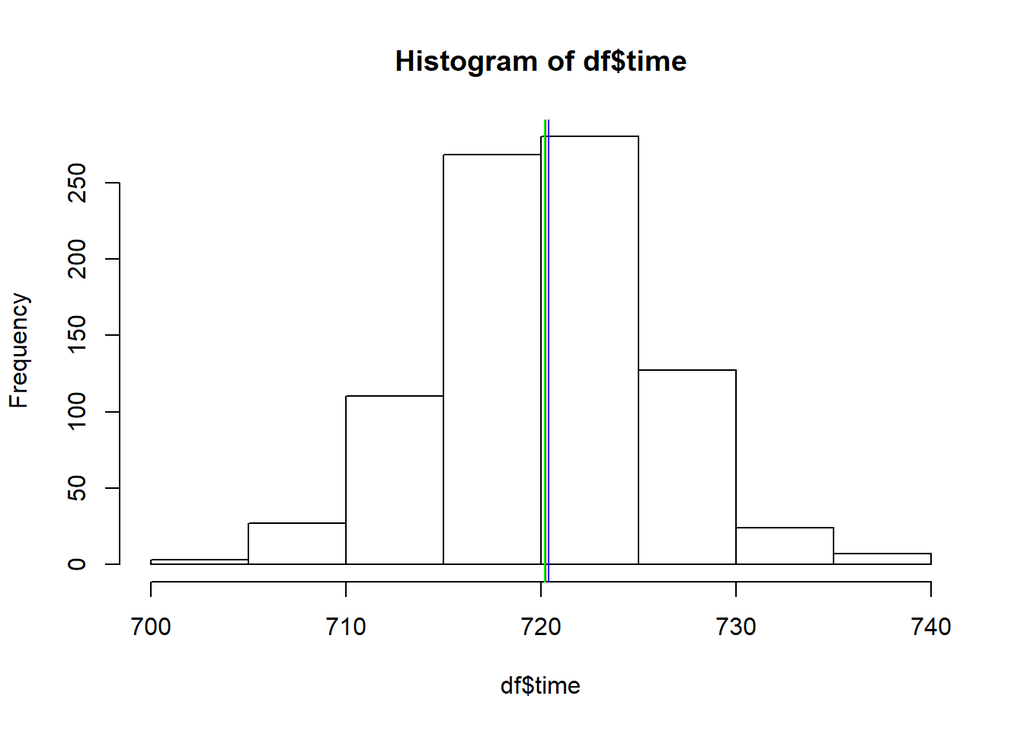

```r
media <- mean(df$time)
mediana <- median(df$time)
moda <- mfv(df$time)
hist(df$time)
abline(v=media, col = 'red')
abline(v=mediana, col = 'blue')
abline(v=moda, col = 'green')
```

### Ejercicio N° 2

- *EJERCICIO* Compara la dispersion de `meta_eff` y `ein_resp`

Para `meta_eff`:

```r
range(df$meta_eff)
```

```
## [1] 307.7392 792.2616
```

```r
IQR(df$meta_eff)
```

```
## [1] 205.1832
```

```r
sd(df$meta_eff)
```

```
## [1] 123.0889
```

```r
var(df$meta_eff)
```

```
## [1] 15150.87
```

```r
gce_cv(df$meta_eff)
```

```
## [1] 0.2247065
```

Para `ein_resp`:

```r
range(df$ein_resp)
```

```
## [1] 4078.176 5471.183
```

```r
IQR(df$ein_resp)
```

```
## [1] 236.6604
```

```r
sd(df$ein_resp)
```

```
## [1] 191.2998
```

```r
var(df$ein_resp)
```

```
## [1] 36595.63
```

```r
gce_cv(df$ein_resp)
```

```
## [1] 0.03823714
```

### Ejercicio N° 3

- *EJERCICIO A* Explora y compara `en_intake` y `ein_resp`en terminos de skewness

Para `en_intake`:

```r
skewness(df$en_intake)
```

```
## [1] 0.7047799
## attr(,"method")
## [1] "moment"
```

Para `ein_resp`:

```r
skewness(df$ein_resp)
```

```
## [1] -0.6094313
## attr(,"method")
## [1] "moment"
```

```r
kurtosis(df$en_intake)
```

```
## [1] 2.880872
```

```r
kurtosis(df$ein_resp)
```

```
## [1] 4.027426
```